# Racket：一门用于编写编程语言的编程语言 • Robby Findler • YOW! 2015Racket: A Programming-Language Programming Language • Robby Findler • YOW! 2015

4 年前（2022 年 12 月 27 日）——51:424 years ago (Dec 27, 2022) — 51:42

[视频 / Video](https://www.youtube.com/watch?v=qqeteRf2GW8)[GOTO Conferences](https://www.youtube.com/@GOTO-)[幻灯片源代码 / Slide source](https://github.com/rfindler/lambdajam-2015-racket-pl-pl/tree/4c9001dca9fb72c885d8cc1bef057ac8f56c24d0)

**目录 / Contents**

- 开场与多语言编程Opening and language-oriented programming
- Scribble：文本也是程序Scribble: text as a program
- Typed Racket 与契约Typed Racket and contracts
- 惰性序列与跨语言互操作Lazy streams and interoperability
- 编译器的架构与可复用组件Compiler architecture and reusable cases
- 为什么传统 C 宏会出错Why traditional C macros go wrong
- 实现短路 or 的挑战The short-circuiting or challenge
- 卫生性与作用域Hygiene and scope
- 用编译期信息实现枚举检查Compile-time information and enum checking
- mini-hdl：电路与门延迟mini-hdl: circuits and gate delay
- mini-hdl 的实现Implementing mini-hdl
- Racket 源码中的语言生态Languages in the Racket distribution
- 结语与致谢Conclusions and acknowledgments
- 问答：并行、互操作与可扩展性Q&A: parallelism, interoperability and extensibility

## DrRacket 与 Racket 程序Dr. racket and racket programs

Host

嗨，欢迎来到 Lambda Jam 的第二天，也就是 Lambda Jam 的最后一天。今天我们要以第三场主题演讲开场，主讲人是我的朋友兼同事、来自西北大学的 Robby Findler。他要讲的是 Racket。你们可能不知道，有这么一窝疯狂的人，研究 Scheme、Racket 之类的东西，他们个个都非常有意思。让我们欢迎 Robby。Hi, So welcome to the second Day of Lambda Jam, also known as the last day of Lambda Jam, And today we're going to start off with our third keynote done by my friend and colleague Robbie Findler, who's at Northwestern University. He's going to be talking about racket in case you don't know there's this nest of crazy people who work on scheme and racket, and stuff like that, and they're all very interesting people. Let's welcome Robbie.

[figure not shown]

幻灯片 1 · Racket：用于编写编程语言的编程语言；Robby Findler，西北大学与 PLTSlide 1 · Racket: a programming-language programming language — Robby Findler, Northwestern & PLT

**幻灯片文字 / Slide text**

```
Racket:
a programming-language
programming language
Robby Findler
Northwestern & PLT
```

Robby Findler

谢谢，谢谢。好，这个标题可能有点奇怪，所以我想通过写一点程序，让大家体会一下我这个标题到底是什么意思。这是 DrRacket，而 Racket 程序总是以一条声明开头，说明自己使用哪门编程语言。所以我先用另一门语言。这是我们为编写文本而构建的一门编程语言。你可以说，比如……不是 G 数，假设我们想写一篇关于斐波那契数的小文章。Thanks, thank you. Okay, So this is maybe a little bit of a strange title, so I wanted to try to give you a sense of what I mean by that title by just doing a little programming, So this is Dr. racket and racket programs always begin with a declaration saying what programming language that they're in and so i'll start with a different one, So this is a programming language we built for writing texts, so you say like not G numbers say we want to write a little essay about fibonacci numbers.

它们很美，有数学，诸如此类，螺旋，大自然，太棒了。好，最前面几个是 1、0、1。让我看看，1、2、3、5、8、13、23，我也不知道，等等。好，大概就是这样。好，这是一门编程语言。我要强调，这是一门编程语言，尽管我连 beautiful 这个词都不一定拼得对。还有这里。They're beautiful, They have math, blah, blah spirals nature awesome, Okay, the first few are one zero one, Let's see one two three five eight thirteen 23 I don't know etc. Okay, something like that all right. So this is a programming language. Okay, I want to emphasize that this is a programming language, despite my ability to spell the word beautiful it's And this here.

## 修改标题以反映函数在文本中的用途Changing the title to reflect the function's purpose in the text

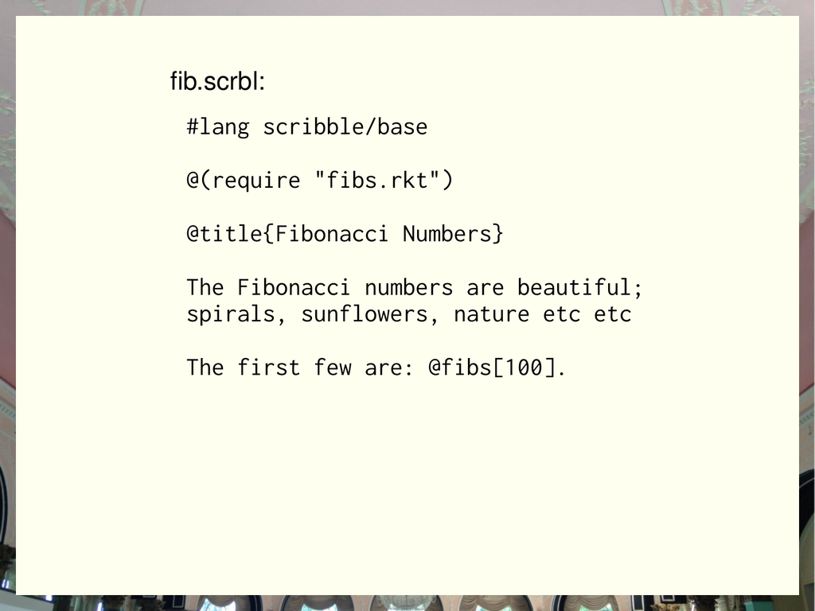

幻灯片 2 · 演示的最终代码：用 Scribble 编写斐波那契数文章Slide 2 · Final demo code: a Fibonacci essay in Scribble

**完整演示源代码 / Complete demo source: fib.scrbl**

```
#lang scribble/base

@(require "fibs.rkt")

@title{Fibonacci Numbers}

The Fibonacci numbers are beautiful;
spirals, sunflowers, nature etc etc

The first few are: @fibs[100].
```

**幻灯片文字 / Slide text**

```
fib.scrbl:
#lang scribble/base
@(require "fibs.rkt")
@title{Fibonacci Numbers}
The Fibonacci numbers are beautiful;
spirals, sunflowers, nature etc etc
The first few are: @fibs[100].
```

语法受 LaTeX 启发，所以我们用 @ 符号代替反斜杠。不过，像这里的 title，这是一个函数。好，哦，我们可以运行它。如果运行它，如果运行它，就会看到这个输出，渲染出来的漂亮的斐波那契数输出。我们也可以把它渲染成 PDF 文件，后端使用 LaTeX 来完成。还有这里，这是一个函数。The syntax is inspired by Latex, and so we use a at sign instead of a backslash, but like this title here, this is a function. Okay, Oh, and we can run it, so if we run it, if we run it, we'll see this output rendered beautiful fibonacci number output, We can render it as a pdf file, and it uses Latex in the back end to do that, and this here's. This is a function.

这个导入的东西直接来自这门编程语言。而且，你知道，还有其他函数。比如，我们喜欢这里的数学，还有，我也不知道，我们喜欢大自然。如果这么做，那么这些函数就会被调用，我们的文本就会呈现出我们预期的样子，对吧。This imported comes directly from the from the programming language and like you know, there's other ones we can like we like math here, and I don't know we like we like nature, and if we, if we do that, then you know, then these functions are called and our text turns the way we expect it to take right.

## 斐波那契数列分析Fibonacci Sequence Analysis

好，既然这是一门编程语言，而且你们有些人在我输入时已经注意到，我好像不怎么会算术。你知道，我们不该……重要的是，它是一门语言，所以为什么不用它来编程呢？斐波那契数大概是世界上最糟糕的递归函数示例。Okay, So since this is a programming language and as a few of you noticed like as I was typing, I think that I sort of can't do math here. You know we shouldn't it's importantly language, so why don't we use it to program right? The fibonacci numbers are like the world's worst example of recursive function.

所以我们就来写它吧，而且用另一门编程语言。这是一门处理文本的编程语言，那我们就用一门适合写小函数的编程语言。斐波那契函数是这样写的。看，如果 N 是 0，结果就是 0。如果 N 是 1，结果就是 1，否则就把前两个斐波那契数加起来。So let's totally write that okay, and let's use a different programming language, so this is a programming language for text, so let's use a programming language for like little functions. So here's how you write the fibonacci. See if N is zero then it's zero. If N is one, then it's one and otherwise we take the sum of the previous two fibonacci numbers.

抱歉，是 2。那我们看看。我们可以做这样的事情，这样我就不用自己做算术了。现在，我们想在另一个文件里使用这个函数，而那个文件是文本。因此，要从这里得到文本，我们就得生成一个字符串，所以可以在这边把它构建出来。Sorry, two, so this is let's see, so we can do things like this, and I don't have to do the arithmetic here. And now we want to use this function back in the other file, and then that's text, and so what we do to be able to get text out of this is we have to make a string, so we can you know build that over on this side.

如果我们写一个接收数字的函数，想返回到那个数为止的所有斐波那契数，就可以用 build-list，我想是 n 和 fib。来看看，我输入 fibs，参数是 10。对，这就是前 10 个斐波那契数，然后把它们变成字符串，再看看，在它们之间加一些逗号。看看效果如何。对，好，然后把它们合成一个字符串。So if we make a function that takes in a number and we want to turn all the fibonacci numbers up to that number, we can say build list I think it's n fib. Let's see so I say fibs of 10 Yeah, so that's the first 10 fibonacci numbers and then turn them into strings and let's see, add some commas between them. Let's see how we're doing here. Yeah, okay, and then make it into one string.

好，我们可以把这些东西组合起来，然后导出它。这就在这里。让我保存一下。这和 title、bold、italic 这些函数的工作方式一样。Okay, so we can put all this stuff together and then we can export it, and this is here. Let me save this. This is the same way that functions like title and bold and italic work.

只不过它计算的是不同的东西。我们可以 provide 它，然后在这边 require 它，再在这里写 fibs，参数为 10。这里 title 参数外面的大括号表示，这个参数是文本。所以在 Scribble 编程语言里，大括号就是用来界定文本的。Except for you know, this compute something different and we can provide it, and then over here we can require it, and then we can say fibs of 10 here and the curly braces here for the argument of title mean that the argument is text, so curly braces are the way that you know that you delimit text in the scribble programming language.

## 类型系统的困境The Type System's Dilemma

而这里我用了方括号，表示里面的参数就是相应的值，在这个例子里是数字 10，其他值也一样。那么，如果我运行这个，好，现在，我不知道你们看不看得见，算术结果稍微好一点了，对吧。如果愿意，我们还可以多算几个，那应该挺酷的，也许就再多几个。And here I've got square brackets and that means that the arguments inside are like the number 10 in this case, whatever they are. And so if I if I run this one, then okay now the I don't can see that not that the math is a little better. Right, We can we can do a few more if we wanted to be, that would be cool, maybe just a couple more.

好，如果你是个编程语言迷，看这段代码可能会有点不满意，因为这个函数显然是可以赋予类型的，对吧。所以你可能想要多一点检查，想提升软件质量，于是你会说：好，这是一个会有很多人想用的库，所以我想用……Okay, So if you're a peel Wonk, you're looking at this code and you're sort of dissatisfied by it a little bit because this is an eminently typable function. right, So you know it's kind of like maybe you want a little more. Checking You want to improve the quality of your software, so you're like Okay, This is a library, Lots of people are going to want to use, so I want to use.

我想给它加上类型。你可以说，好，我希望它使用 Typed Racket，而不只是普通的 Racket，然后类型检查器……I want to use types for it, so you can say okay, I want this to be in typed racket, not in just a regular racket, and the type checker.

类型检查器生气了，因为我们没有写声明，而它默认作出的假设在这里不对。所以，如果我们说这是一个从整数到整数的函数，那么，好，事情就顺利起来了，比如这里有些东西的类型会显示出来。我再给这个函数加上类型声明，它是从整数到字符串的。右下角那个你们可能看不见的小绿点，那个小小的小绿点，表示类型检查器对此很满意。The type checker gets angry because we didn't put declarations and the default things it assumes are not correct here, so if we say this is a integer to integer function, and then okay, then good things are happening like we We get types here on some of these things, and I give a type declaration on this one, This one's integer to string, and that little that little, that little green dot that you probably can't see on the bottom right corner means that the type checker was happy with this.

现在运行程序，它就会说使用的是 Typed Racket，而不是普通的 Racket。而当我运行这样的东西时，它在开始求值之前就会告诉我结果的类型。所以，即使发生了运行期错误，我仍然已经看到那条紫色的提示，说它是字符串。好，我可以回到这边，而这个仍然可以工作。And so now when I run the program, it's it says it's in typed racket, not regular racket, and when I run something like this, it tells me the type of it before it starts the evaluation, so there's been a runtime error. I still have seen that purple line there saying that was a string. Okay, So I can you know I can go back over here and this still works.

好，这里，不如做点别的？我们就看看前两个，让你们相信它现在确实能运行。好，不过这里有一件挺有意思的事：Scribble 和 LaTeX 一样，是一门无类型的编程语言。所以我们是从无类型的编程语言调用有类型的编程语言，这很危险，对吧。来看看，比如，我也不知道，这就是 Racket 里 true 的写法。Okay here, No, Why don't I do something like? Let's just see the first two of them, so you believe that it really runs now. Okay, and but one thing that's kind of interesting about This is that scribble like Latex is an untyped programming language and so we're calling from an untyped programming language into a typed programming language which is dangerous. right. Let's see so like I don't know That's the way you spell true in racket.

如果运行它，哦，类型系统知道……我们回到另一个文件。类型系统知道这是一个从整数到整数的函数。它不知道的是，这个函数会在哪里使用。因此，它知道这个整数没问题，而且……类型检查器已经证明，这个函数总是返回整数。So if I run that, oh, so the type system knows, let's go back to the other file type system knows that this is a function from integers to integers. What it doesn't know is where this function is going to be used, and so it knows that this integer is good and that it's. The type checker has proven that this function always returns an injure.

但是，它并没有证明这个函数被调用时，传入的总是整数，因为就在这里，调用它时传入的并不是整数。所以，它会加上一份契约，确保输入确实是整数。这就是输入不是整数时得到的错误消息。这就是 Racket 的一个组成部分。It has not however proven that this function is always called with an integer because like right there, it didn't it didn't get called as an insurance, So what it does is it puts a contract on to make sure that the you know that the input really isn't injured, and this is the error message you get when it's not so that's one piece of racket.

## 喂鸡Chicken Feeding

要成为一门用于编写编程语言的编程语言，就得有很多这样的东西。那么，把这个改回去。有谁知道会发生什么吗？如果我……如果在这里再加一个 0？我听到了一些嘀咕，几乎可以肯定那就是正确答案。There's a lot of stuff like that goes into having being a programming language, programming language. So let's put this back. anybody know what happened If I. If I put another zero here, I'm hearing mumbling, which is almost certainly the right answer.

我们还是把它停掉吧。因为如果看这里，这个栈跟踪基本上……它跳过了，我不知道你们能不能看清，这里最上面写着，跳过 25 个重复的栈帧。因为用这个算法计算第 120 个斐波那契数会花很长时间，对吧。所以我们都知道怎么解决，对不对。Let's just stop that because that's like if you look at this, the stack trace here is it's basically it's so skip I don't know if you probably can read this, but here at the top it says it says skip 25 duplicate frames because this is like Gonna. Take a long time to compute fibonacci of 120 with this algorithm right and so we all know how to fix this right.

计算第 N 个斐波那契数的标准方法，只需要做 N 次加法，而不是像这个算法这样，做指数数量的加法，就是把前一个值累积起来，对吧。好，不过，这可满足不了那个研究“用于编写编程语言的编程语言”的家伙，对吧。有没有更好的办法？如果我们还有另一门编程语言呢？You, the standard way that you can compute the Nth fibonacci numbers with only N uses of addition instead of like some exponential numbers of additions. Which is what this algorithm does? is you accumulated with the previous value? Right, Okay, but that's not going to satisfy the programming language programming language or guy right, what's a. Is there a better way that we could do this? if we had another programming language?

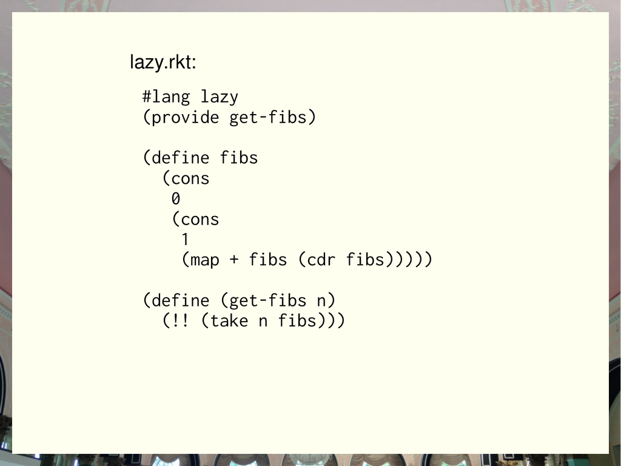

幻灯片 3 · 演示的最终代码：惰性斐波那契序列与严格求值接口Slide 3 · Final demo code: lazy Fibonacci streams and a strict interface

**完整演示源代码 / Complete demo source: lazy.rkt**

```
#lang lazy
(provide get-fibs)

(define fibs
  (cons
   0
   (cons
    1
    (map + fibs (cdr fibs)))))

(define (get-fibs n)
  (!! (take n fibs)))
```

**幻灯片文字 / Slide text**

```
lazy.rkt:
#lang lazy
(provide get-fibs)
(define fibs
  (cons
   0
   (cons
    1
    (map + fibs (cdr fibs)))))
(define (get-fibs n)
  (!! (take n fibs)))
```

也许有。我们可以说，斐波那契数是一串数字，开头是 0，接着是 1。后面的 Conal 已经知道接下来是什么了。然后后面跟着……你们有人用流编过程吗？Maybe so this is so we can say the fibonacci numbers are a sequence of numbers that begin with zero and then have one and connell's back there knows what's coming, then are followed like and so any of you programmed the streams before.

好，如果没有，我就用两秒钟解释一下这段代码在做什么。这是斐波那契数的无限流。它说的是，第一个斐波那契数是 0。So okay, i'll give you the two second version of what this code is doing if you haven't, but this is This is the infinite stream of fibonacci numbers, and what it says is the first fibonacci number is zero.

第二个斐波那契数是 1，接下来是 map 加上 +。如果你知道 Haskell，这就像 zipWith，或者说像 map，不过这里 + 接收两个参数。因此，你传给它两个流，在这个例子里是无限流，不过两个列表也可以。所以，它做的是：cdr fibs 就是取出斐波那契数，丢掉第一个。你可以把它想成一个没有第一个数的斐波那契数流。而 fibs 是包含所有斐波那契数的流。因此，它就是沿着这两个流逐项两两相加，把结果构成一个新的流，而这就是全部的 fibs。The second fibonacci number is one, and then map plus, So if you know Haskell, this is like Zip width or this is like map, but where plus is getting two arguments, so you give it two in this case infinite streams, but two lists also So what it's doing is it's like cuter Fibs is like take the fibonacci numbers, drop the first one, so you can think of that as a stream of all the fibonacci numbers without the first one, and then Fibs is a stream of all the fibonacci numbers, and so what it's doing is it's just doing pairwise edition all the way along them and making a new stream out of that, and that is all the fibs.

## 惰性编程语言中的互操作性挑战Interoperability Challenges in Lazy Programming Languages

我们可以输入 fibs，得到前 10 个；也可以输入 take 100 fibs。惰性在这里发挥了很好的作用，让这一切能够工作。如果取前 1009 个斐波那契数，打印它们花的时间比计算它们还长。好，我们把它封装起来，拿回严格求值的世界里使用。那么，来个 get-fibs，参数为 N，怎么样？So we can say fibs and we get the first 10, and we can say take 100 fibs and laziness does good things here that like make this work. If I take the first 1009 fibs, it takes longer to print them than to compute them. Okay, And so let's package that up for use back in strict land. So how about get fibs of N.

然后我们要在里面放上……惰性编程语言和严格编程语言之间的互操作性，不像有类型和无类型编程语言之间那么完善。因此，这里需要一点互操作的胶水代码，基本上就是那个 ! 函数。这个感叹号函数的意思就是：现在就取得这个值。我们把它放在即将把东西传回严格语言之前的位置。And then we want to put in there and we don't have as good an interoperability story between the lazy programming language and the strict programming language and the way we do between typed and untyped programming languages, And so there's a little bit of like interrupt glue code there, which is that bang function basically, and what the bang function means is like get the value now and then so, and we'll put that right before we would cross things back over to the to the strict language.

好，现在我们可以摆脱这个糟糕的东西，然后说，在这里，看看，我们想做的是……现在不想这么做了，而是要调用 get-fibs，参数为 N。当然，get-fibs 现在还是个自由变量，因为我还没有引入那个库。而这门惰性语言是一门无类型的惰性语言，因此，在连接有类型和无类型编程语言时，我们又遇到了之前同样的问题。Okay, And then so now we can get rid of this abomination and say well here, Let's see so what we want to do is We don't want to do this now, we want to say get fibs of N and of course, get fibs is a free variable now because I haven't pulled in that library and this This lazy language is an untyped lazy language, so we have the same problem we had before with connecting between the typed and an untyped programming language.

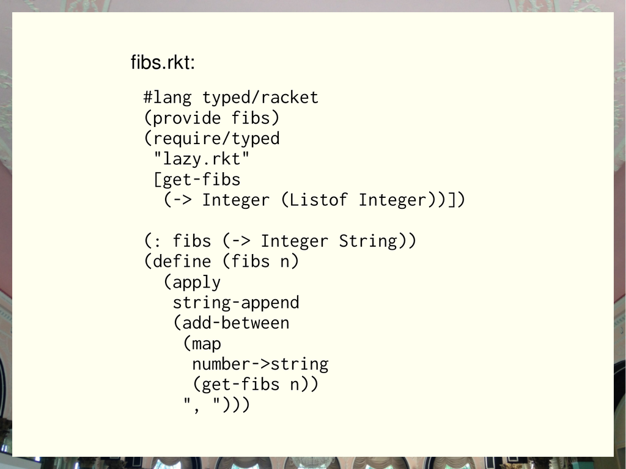

幻灯片 4 · 演示的最终代码：Typed Racket 调用惰性语言Slide 4 · Final demo code: calling the lazy language from Typed Racket

**完整演示源代码 / Complete demo source: fibs.rkt**

```
#lang typed/racket
(provide fibs)
(require/typed
 "lazy.rkt"
 [get-fibs
  (-> Integer (Listof Integer))])

(: fibs (-> Integer String))
(define (fibs n)
  (apply
   string-append
   (add-between
    (map
     number->string
     (get-fibs n))
    ", ")))
```

**幻灯片文字 / Slide text**

```
fibs.rkt:
#lang typed/racket
(provide fibs)
(require/typed
 "lazy.rkt"
 [get-fibs
  (-> Integer (Listof Integer))])
(: fibs (-> Integer String))
(define (fibs n)
  (apply
   string-append
   (add-between
    (map
     number->string
     (get-fibs n))
    ", ")))
```

不过，这里没有类型声明来指导互操作，所以我们得在这边写出来。你可以写 require/typed，引入 lazy 里的东西。我想要 get-fibs 函数，它应该具有这样的类型，列表，里面是……究竟是什么来着。而且我应该在这边 provide 它。But here there's no like type declaration to guide the interop, so we have to like write it over here, so you say require typed of lazy, and I want the get fibs function, and it should have this type list of Sure what though, and I should provide it over here.

现在，这段代码的意思是：亲爱的类型检查器，请假设这是正确的类型，并证明你遵守了它，完成之后就变绿。然后，通过契约系统插入类似的动态检查，确保无类型那一边遵守了你在这里所作的声明。And now, what this is saying is assume, dear type checker, Please assume that this is the correct type and prove that you obey it, and then turn green when you've done that and in certain similar kind of dynamic checking via the contract system to make sure that the untyped side is obeying what you've declared here.

## 编译器的架构：一个关于 Lambda 函数与惰性的故事The Architecture of Compilers: A Tale of Lambda Functions and Lazy

所以，在这个例子里，我们知道调用 get-fibs 时传入的会是整数，而必须检查的是它返回的确实是整数列表。不过，我们先把它放回文章里。现在按下这个按钮，应该就会得到结果。嘿，这就是我们漂亮的数学螺旋。So, in this case, we know that get FIB is going to be called with an integer and we have to check that it returns a list of integers. But here, let's just put this back in the essay now, so now I can hit this button and I should get things And hey, and there's our, there's our beautiful matte spirals.

好，好，这就是在这门“用于编写编程语言的编程语言”里编程的一点体验。接下来这场演讲，我想让大家稍微了解一下，使这一切得以运作的技术。Okay, Okay, so that's a taste of programming in the programming language, programming language, and what I want to do for the rest of this talk is Try to give you a little bit of a glimpse into the technology that makes it work.

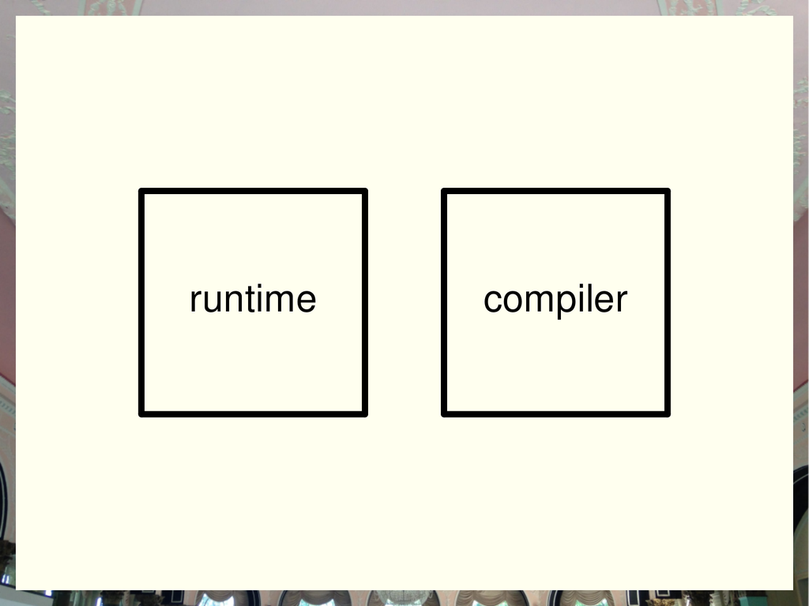

幻灯片 5 · 语言实现的两个组成部分：运行时与编译器Slide 5 · Two parts of a language implementation: runtime and compiler

**幻灯片文字 / Slide text**

```
compiler
runtime
```

这里是一门语言的实现，也就是编译器的架构示意图。其实我只想聚焦于编译器，所以我们稍微看看这个框的内部。So here is a picture of an architectural diagram of a compiler, of an implementation of a language all right, and really I just want to focus in on the compiler, and so let's look inside that box a little bit.

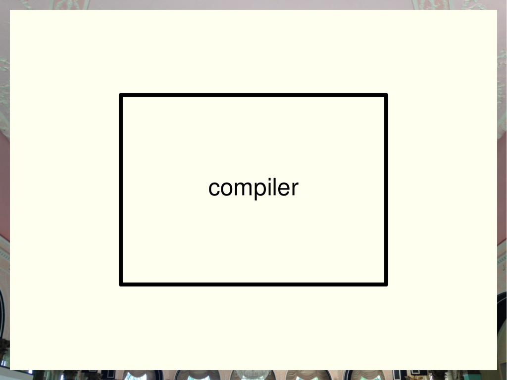

幻灯片 6 · 聚焦编译器内部Slide 6 · Focusing on the compiler

**幻灯片文字 / Slide text**

```
compiler
```

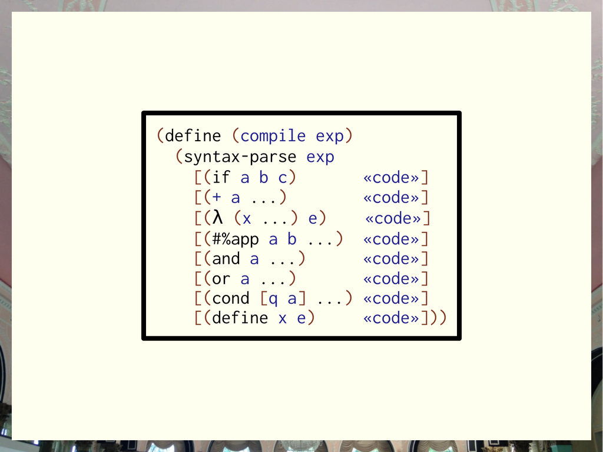

幻灯片 7 · 编译器通过模式匹配处理不同的语言形式Slide 7 · A compiler handles language forms through pattern matching

**幻灯片文字 / Slide text**

```
(define (compile exp)
  (syntax-parse exp
  [(if a b c)       «code»]
[(+ a ...)        «code»]
[(λ (x ...) e)    «code»]
[(#%app a b ...)  «code»]
[(and a ...)      «code»]
[(or a ...)       «code»]
[(cond [q a] ...) «code»]
[(define x e)     «code»]))
```

如果打开一个编译器，你会预期看到一个函数，里面有一个巨大的 case 语句，就像这个。编译器接收一个表达式，然后对它进行某种模式匹配。如果是条件表达式，就做这件事；如果是加法，就做那件事。If you open up a compiler, you expect to find it like a giant, a function with a giant case statement in it like this one, so the compiler takes in an expression and then does some kind of pattern matching on the expression. And if it's a conditional, it does this thing and if it's an addition, it does that thing.

如此等等。如果你去看 Scribble、有类型语言、普通 Racket 语言、惰性语言，或者我们其他编程语言的实现，这些框看起来都会非常相似。And blah Blah, blah, And if you were to look at the implementation of scribble or of the typed language or the regular rocket language of the lazy language, or like any of the other programming languages, we have you, These boxes would all look very similar to each other.

我的意思是，惰性编程语言和严格编程语言之间确实存在重要的区别，但就编译器实现中相差的字符数量而言，差别很小。类型检查器也是一样，对吧。事实上，很多类型检查器，很多有类型的编程语言，在很长一段时间里……I mean, there's important differences between a lazy programming language and a strict programming language, but in terms of the like delta number of characters and the implementation of the compiler is small and the same thing for the type checker right. In fact, many type checkers, many types of programming languages for a long time.

它们的实现策略基本上是，先进行类型检查，再使用某种相近编程语言的无类型编译器来编译。好，Typed Racket 比这稍微聪明一点，不过如果从这个粒度来看，差别真的不大。所以，我们想实现的那种魔法，就是能够重用大量代码，来实现所有这些语言。Their implementation strategy was basically do the type checking and then compile it using the untyped compiler for the for a sort of a similar programming language, all right and type dragons is a little bit smarter than that, but there's really not a lot of difference if you're looking at this level of granularity and so kind of the magic that we want to make work to be able to reuse a lot of code, to be able to implement all these languages.

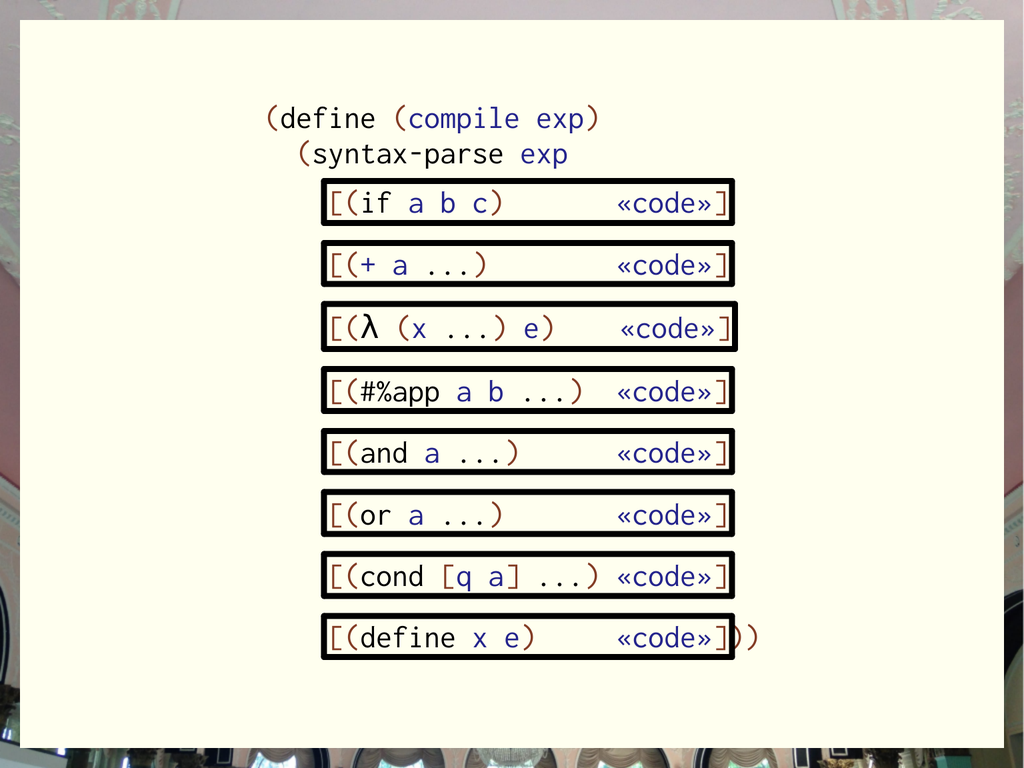

幻灯片 8 · 把编译器的各个分支视为可复用组件Slide 8 · Treating compiler cases as reusable components

**幻灯片文字 / Slide text**

```
(define (compile exp)
  (syntax-parse exp
  [(if a b c)       «code»]
[(+ a ...)        «code»]
[(λ (x ...) e)    «code»]
[(#%app a b ...)  «code»]
[(and a ...)      «code»]
[(or a ...)       «code»]
[(cond [q a] ...) «code»]
[(define x e)     «code»]))
```

## 宏详解：如何混搭编译器Macro Explained: How to Mix and Match Compilers

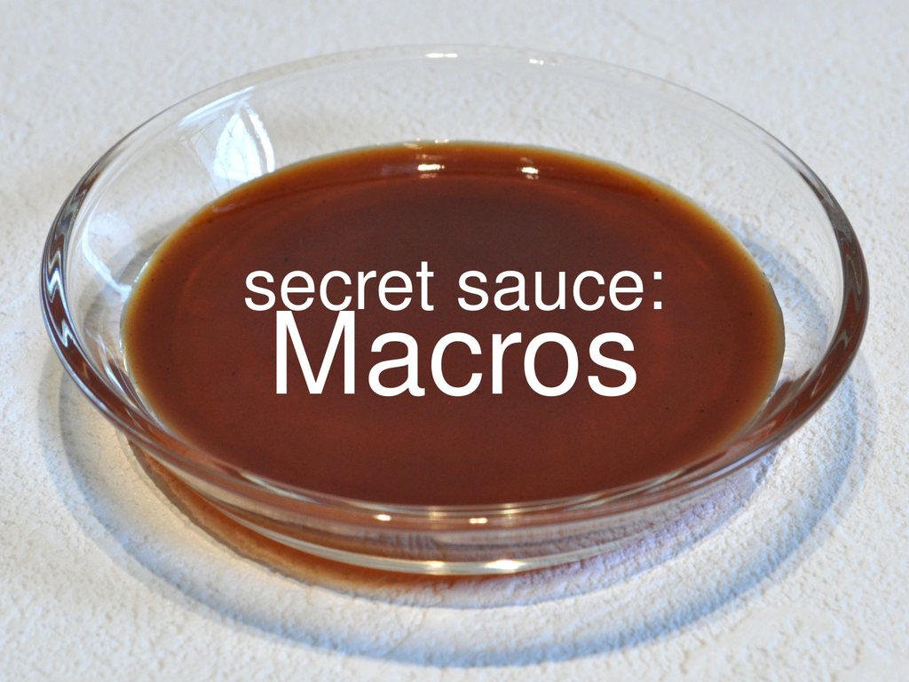

幻灯片 9 · 秘诀：宏Slide 9 · The secret sauce: macros

**幻灯片文字 / Slide text**

```
secret sauce:
Macros
```

我们采用的办法是，在这种框的层次上思考编译器，以及编译器中的重用。我们想把大致对应于编译器中各个分支的框混搭起来，而做到这一点的方法就是宏。让我解释一下，让我试着解释一下。首先，我先定义什么是宏。The way we have is to we want to think about our compiler and the reuse in our compiler at this level sort of boxes of this, and we want to mix and match boxes that sort of correspond to cases in our compiler, and the way we do that is macros. So let me explain, let me try to explain that so first, i'll just define what a macro is.

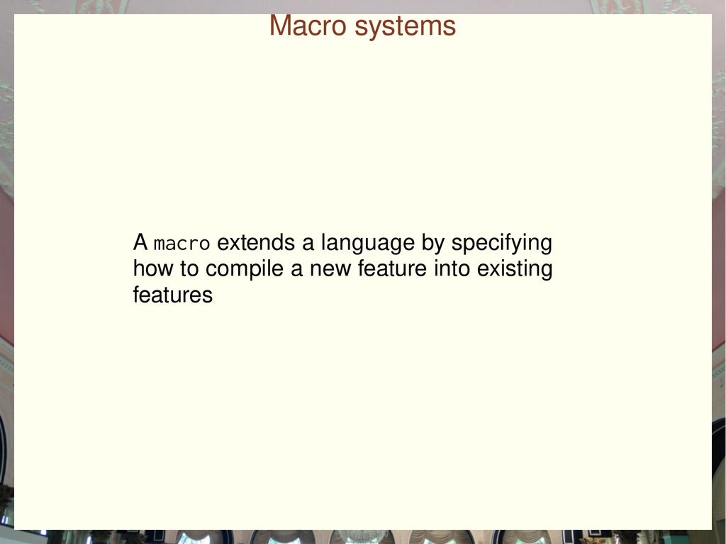

幻灯片 10 · 宏通过把新特性编译为已有特性来扩展语言Slide 10 · A macro extends a language by compiling a new feature into existing features

**幻灯片文字 / Slide text**

```
Macro systems
A macro extends a language by specifying
how to compile a new feature into existing
features
```

宏通过给一门编程语言增加一个特性，并指定如何把这个新特性编译成某些已有特性，来扩展这门语言。如果你考虑在编译器的实现中混搭这些框，那还需要一些别的机制，才能选出其中一部分框，把它们组合成一门编程语言。这是模块系统替你处理的事情，本场演讲里我不会再多讲它。因此，我们就专注于这一个部分：如何通过宏，在一门编程语言中增加一个特性。A macro extends a language by adding one feature to that programming language and specifying how that one new feature compiles into some existing features. And so, if you're thinking about mixing and matching boxes in your compiler's implementation, you need a little bit more to be able to like pick a subset of boxes and put them together into a programming language, and that's something that the module system handles for you, and that I won't really be talking much more about in this talk, So we'll just focus on this one piece of how you can take a programming language and add one feature to the programming language via macro.

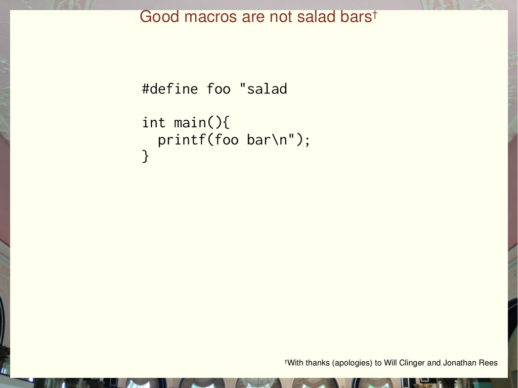

幻灯片 11 · 好的宏不是沙拉吧：传统 C 预处理器会在字符串中做替换Slide 11 · Good macros are not salad bars: textual substitution inside a string

**幻灯片文字 / Slide text**

```
Good macros are not salad bars†
†With thanks (apologies) to Will Clinger and Jonathan Rees
#define foo "salad
int main(){
  printf(foo bar\n");
}
```

好，我得讲一点历史，带大家回到大约 1963 年，那套技术在 gcc traditional CPP 中被保存了下来。如果你用 gcc traditional CPP 运行这个程序，有人知道它会打印什么吗？salad bar，太糟糕了。Okay, and I have to do a little bit of history here and take you back to roughly 1963 as immortalized in gcc traditional CPP, And if you were to run this program in gcc traditional CPP, anybody know what it prints salad bar, which is terrible.

好，好，如果你是个正常人，看这个程序时会在第一行看到一个起始引号，又在下面某一行看到结束引号，然后认为那是一个字符串。但如果你用的是 1963 年的宏技术，你看到的就不是这个。你所做的，就是把 foo 以文本替换成起始引号加 salad，仅此而已。好。Okay, Okay, so if you look at this program and you're like a normal person, you see an open quote on the first line, and you see a close quote on some further line down there, and you think that's a string And if you are in the 1963 technology of macros, that's not what you see. What you do is a textual replacement of foo with open quote salad, and that's all you do. okay.

## 编程中宏系统的陷阱The Pitfalls of Macro Systems in Programming

如今，宏这个词背负了很多历史包袱，所以我要带大家快速回顾一下历史，让我们对什么是好的宏系统达成共同认识。我想指出为什么这是一个糟糕的宏系统。它糟糕，是因为它不尊重编程语言在解析层面的结构，对吧。So now there's a lot of baggage associated with macro, so that's why I'm taking you through this sort of quick tour of history of So we all caught up with what's a good macro system, and I want to point out why this is a bad macro system. Okay, this is a bad macro system because it doesn't respect the parsing level structure of the programming language. Right.

也就是词素结构。编程语言里有字符串这种东西，宏系统应当尊重这一点，不应该在字符串中间胡乱啃咬。好，它是一个糟糕的宏系统，因为它不尊重编程语言在解析层面的结构。好，现在我们赶上了目前的 GCC。不过，按照宏技术以及我们对宏的理解来看，这也已经非常古老了。The lexime structure, there's a thing such as a string in the programming language, and we should respect that in the macro system by not sort of munching in the middle of strings. Okay, that's a bad macro system because it doesn't respect the parsing level structure of the programming language. Okay, now we're caught up with the current GCC, and this is also very old in terms of the macro technology and what we understand about macros.

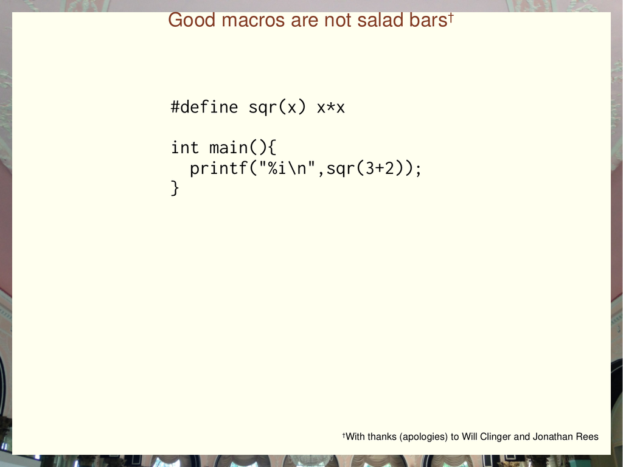

幻灯片 12 · sqr(3+2)：你期望结果是多少？Slide 12 · sqr(3+2): what result would you expect?

**幻灯片文字 / Slide text**

```
Good macros are not salad bars†
†With thanks (apologies) to Will Clinger and Jonathan Rees
#define sqr(x) x*x
int main(){
  printf("%i\n",sqr(3+2));
}
```

那么，有谁知道这个会产生什么结果吗？10 很接近，25 不对。好，25 是你希望它得到的结果，但它实际上得到的是 11。对。好，为什么会是 11 呢？好，因为这个不会展开成那个，虽然一个正常人可能会预期它展开成那个。相反……But anybody know what this produces. 10 is close and 25 is wrong. Okay, 25 is what you would hope would produce and it actually produces 11. Right, Okay, why does it produce 11. all right? Okay, is that this does not expand into that, which is what a sane person might expect it to expand into. instead?

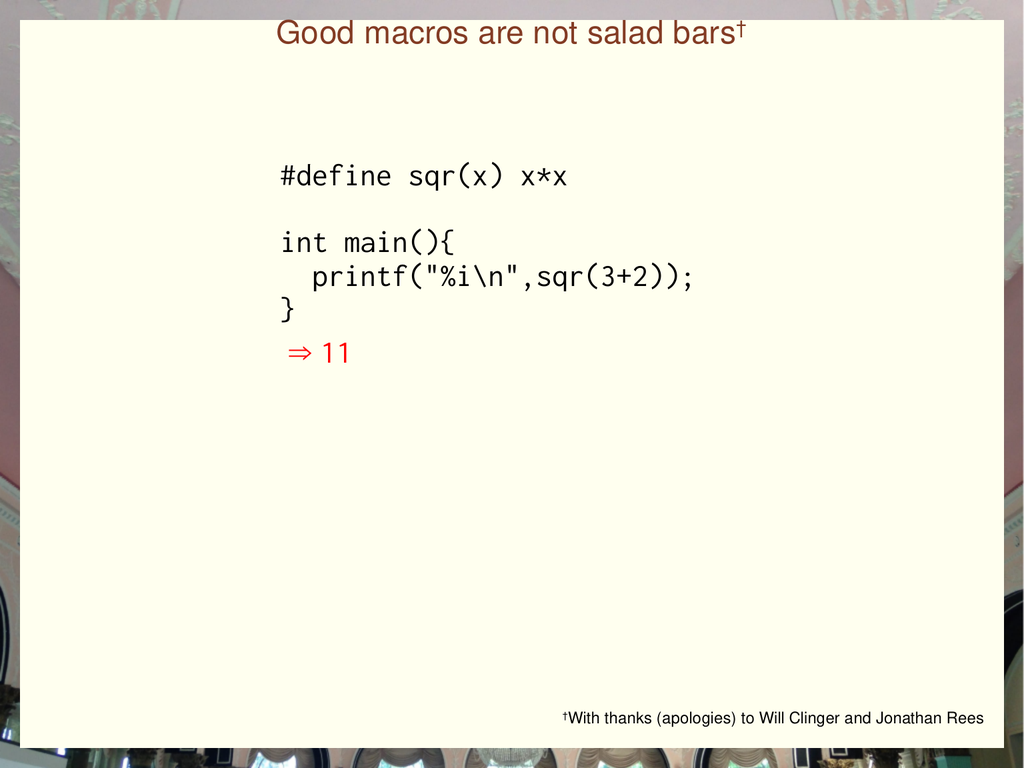

幻灯片 13 · 没有括号保护的 C 宏产生结果 11Slide 13 · The unparenthesized C macro produces 11

**幻灯片文字 / Slide text**

```
Good macros are not salad bars†
†With thanks (apologies) to Will Clinger and Jonathan Rees
#define sqr(x) x*x
int main(){
  printf("%i\n",sqr(3+2));
}
 ⇒ 11
```

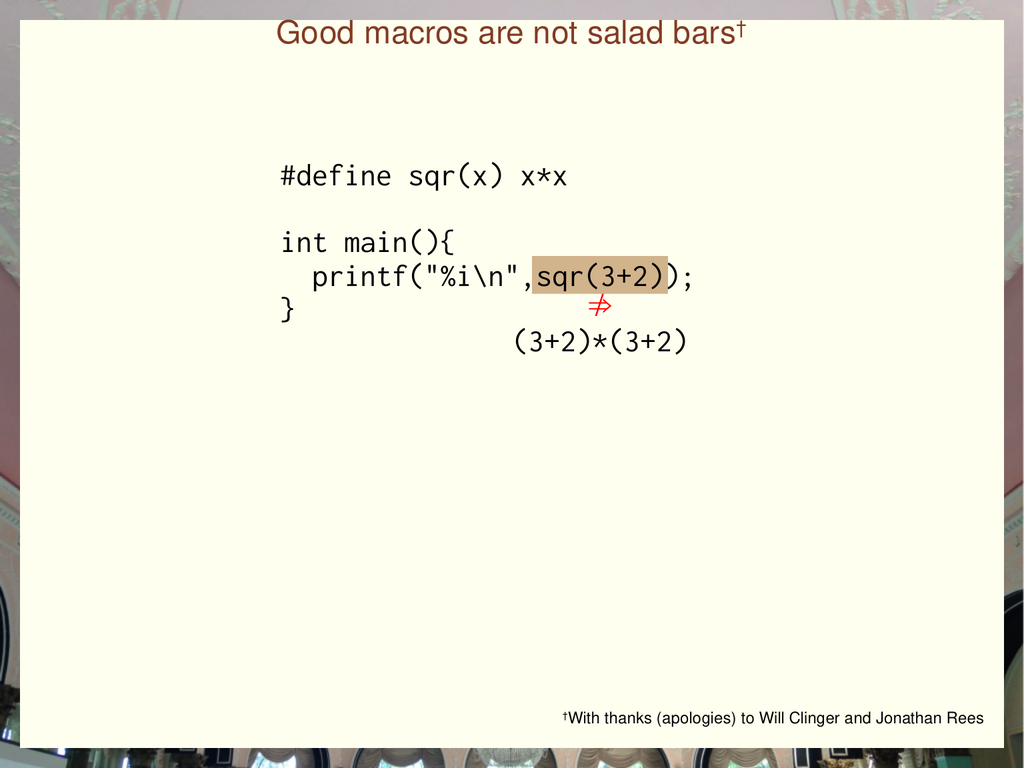

幻灯片 14 · 期望的表达式树：(3+2)*(3+2)Slide 14 · The expected expression tree: (3+2)*(3+2)

**幻灯片文字 / Slide text**

```
Good macros are not salad bars†
†With thanks (apologies) to Will Clinger and Jonathan Rees
 ⇒ /
(3+2)*(3+2)
#define sqr(x) x*x
int main(){
  printf("%i\n",sqr(3+2));
}
```

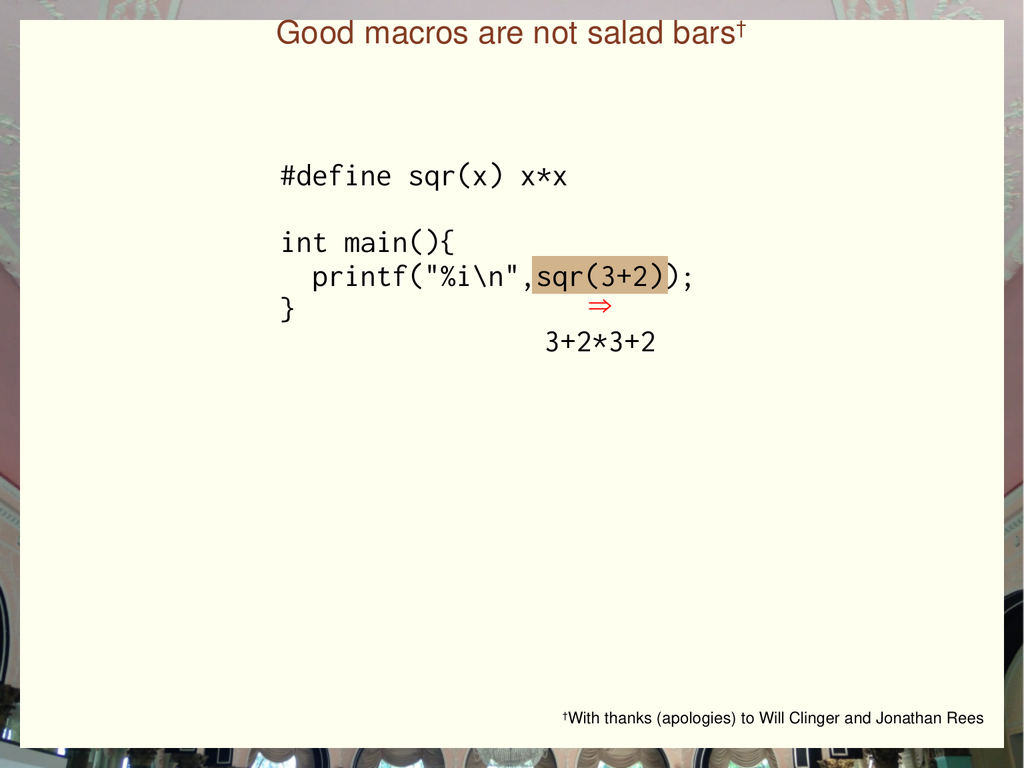

幻灯片 15 · 实际的词法替换：3+2*3+2Slide 15 · The actual token substitution: 3+2*3+2

**幻灯片文字 / Slide text**

```
Good macros are not salad bars†
†With thanks (apologies) to Will Clinger and Jonathan Rees
 ⇒
3+2*3+2
#define sqr(x) x*x
int main(){
  printf("%i\n",sqr(3+2));
}
```

用这个宏替换 3 加 2 时，得到的是这个。如果你记得运算优先级口诀“Please Excuse My Dear Aunt Sally”，它就等同于那个，结果是 11。这也是一个糟糕的宏系统。它糟糕，是因为它不尊重其所在编程语言在表达式层面的结构。What happens when you do the substitution with this macro for three plus two Is you get that and if you please excuse my dear Aunt sally, it's the same as that, which is 11. This is also a bad macro system. Okay, this is a bad macro system because it doesn't respect the expression level structure of the programming language that it plays a host to.

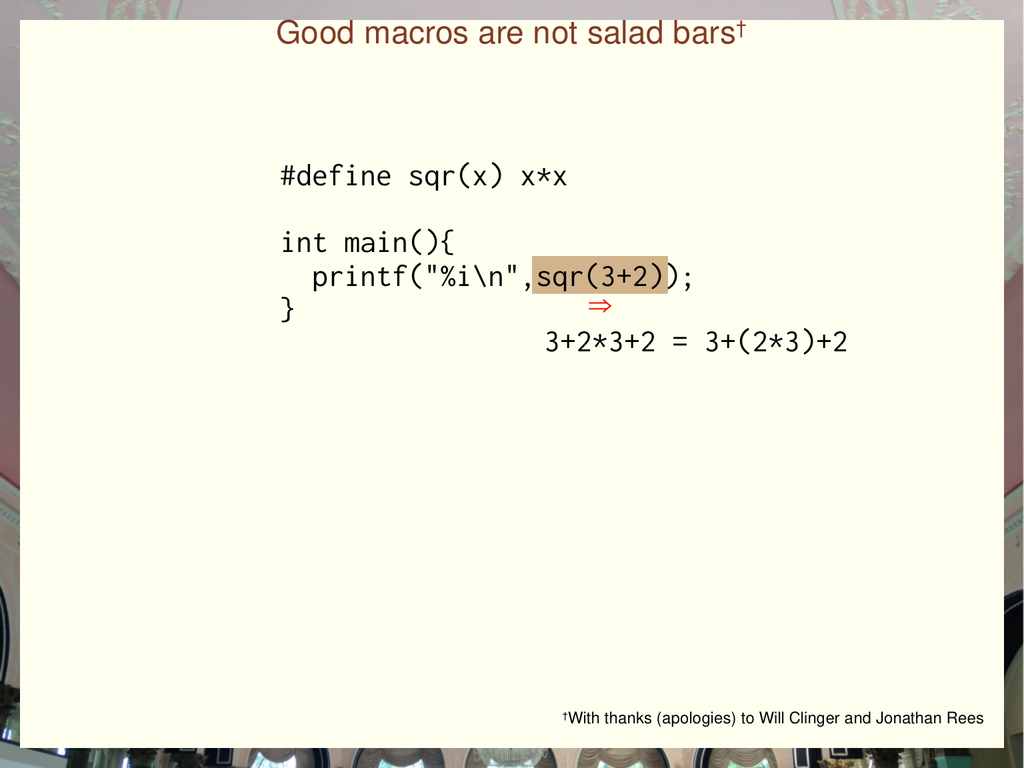

幻灯片 16 · 运算符优先级把表达式解释为 3+(2*3)+2Slide 16 · Operator precedence gives 3+(2*3)+2

**幻灯片文字 / Slide text**

```
Good macros are not salad bars†
†With thanks (apologies) to Will Clinger and Jonathan Rees
 ⇒
3+2*3+2 = 3+(2*3)+2
#define sqr(x) x*x
int main(){
  printf("%i\n",sqr(3+2));
}
```

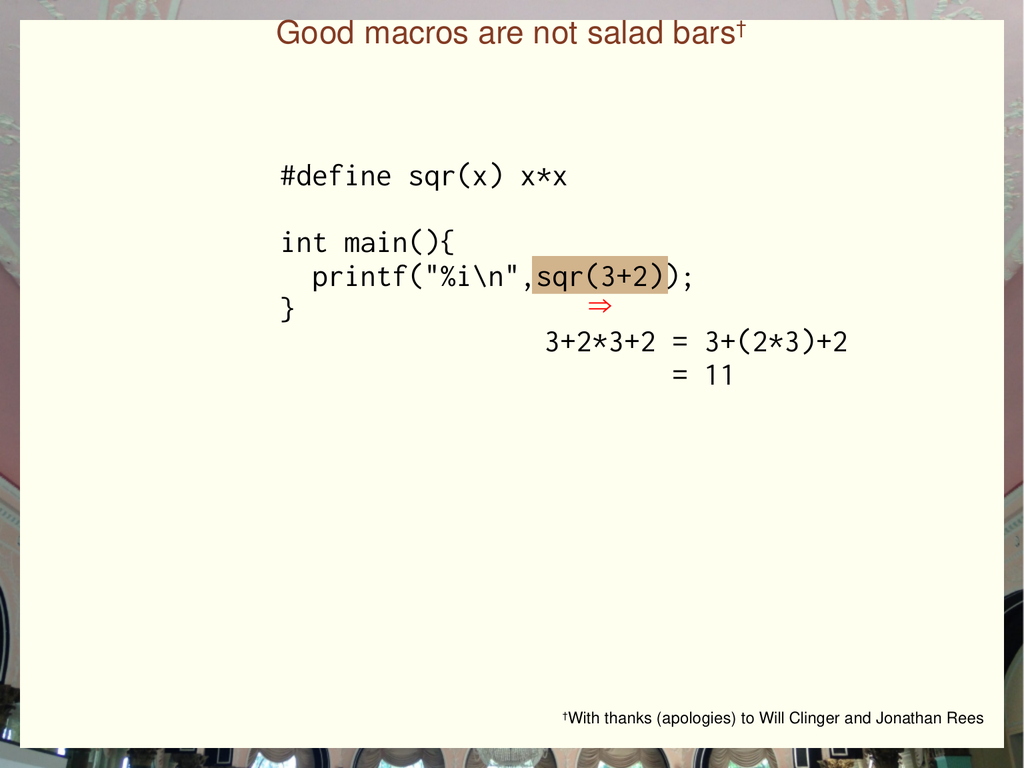

幻灯片 17 · 最终结果仍然是 11，而不是期望的 25Slide 17 · The result is 11, not the expected 25

**幻灯片文字 / Slide text**

```
Good macros are not salad bars†
†With thanks (apologies) to Will Clinger and Jonathan Rees
 ⇒
3+2*3+2 = 3+(2*3)+2
 = 11
#define sqr(x) x*x
int main(){
  printf("%i\n",sqr(3+2));
}
```

所以，作为宏作者，当你写出那样一个宏时，你预期每个 X 出现的位置都会被填入一棵树，而不是一串词元，对吧。你会把 3 加 2 这个表达式想成一棵树，有 3 这个节点，以 + 为节点，3 和 2 是它的子节点。So, when you're a macro writer and you write a macro like that one, you're expecting that each of those occurrences of X is going to have the like a tree plugged in not a sequence of tokens plugged into it right, So you expect that you think of the expression three plus two as a tree with three as the node and with plus as a node and three and two as the children of it.

## 麦乐鸡Chicken McNuggets

然后，在编译期发生的那个宏替换模板操作里，你预期的是把整棵树填进 x 的位置，对吧，而不是基本上只把一串词素填进 x 的位置。好，所以这个宏系统糟糕，是因为它不尊重编程语言的表达式结构。好，好。And then in the macro substitution template thing that happens at compile time, you expect that entire tree to be plugged in for x right, not just the sequence of lexines basically being plugged in for x. Okay, so this is a bad macro system because it doesn't respect the expression structure of the programming language all right all right.

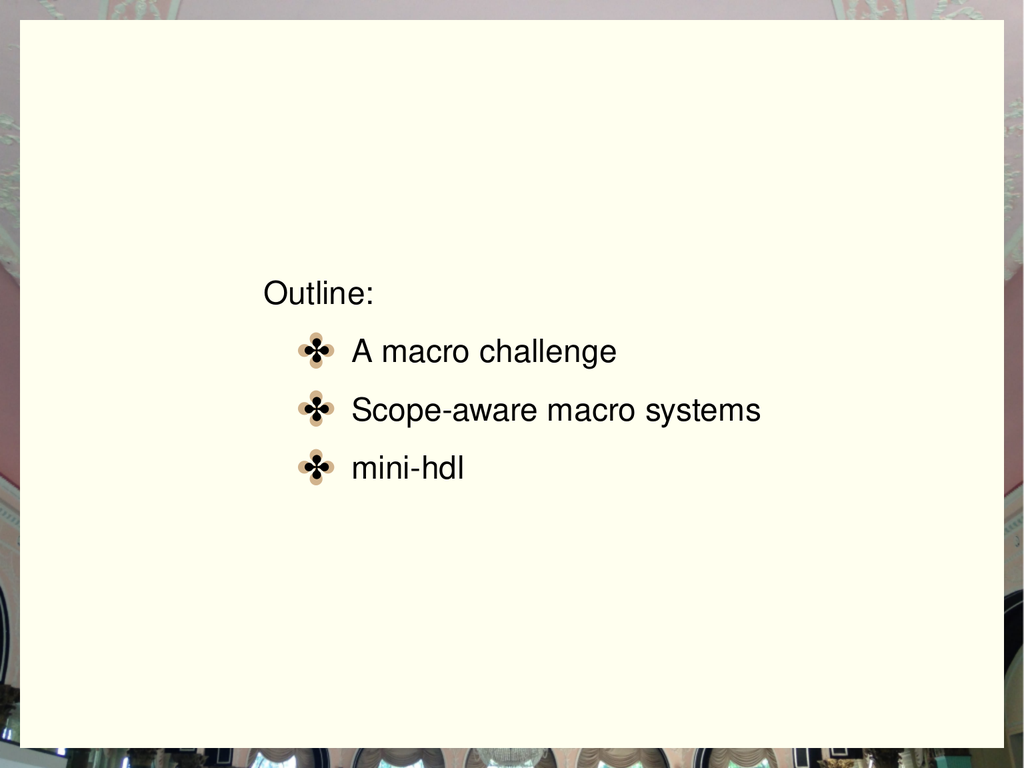

幻灯片 18 · 路线图：宏挑战、理解作用域的宏系统与 mini-hdlSlide 18 · Outline: a macro challenge, scope-aware macro systems and mini-hdl

**幻灯片文字 / Slide text**

```
Outline:
✤
✤A macro challenge
✤
✤Scope-aware macro systems
✤
✤mini-hdl
```

那么，让我花一点时间，更详细地告诉大家这场演讲接下来要往哪里走。接下来我会更详细地介绍宏的定义，并使用 Racket 的记法。然后我会……我把它叫作一个挑战。我会说，我们来实现这个东西，看看实现它需要些什么。So let me let me take a minute here and just tell you in a little more detail where we're going with this talk. I'm going to I'm going to next go through in more detail the definition of a macro, and we'll use racket notation for that. That will i'll call it a challenge. While i'll say, i'll say let's implement this thing and we'll see what it takes to implement that.

然后，我们会由此谈到宏系统可能很糟糕的另一个原因：它不尊重编程语言的作用域，不尊重编程语言在变量层面的结构。And then and then we'll go from, we'll get from that into another reason, a macro system can be bad, namely that it doesn't respect the scope of the programming language, it doesn't respect the variable level structure of the programming language.

接着，我会讲一点，尊重这些结构能带来什么好处，以及我们如何真正开始接近这样一个想法：把编译器拿来，在编译器各个分支的层次上实现重用。And then i'll talk a little bit about how when you do respect that you can get good stuff out and how we get to really start to get close to this idea that we're taking the compiler and sort of getting reused to the level of clauses in the compiler.

## 鸡的悖论Chicken Paradox

前提是你有一个能够正确尊重作用域的宏系统。然后，我会展示一门为这次演讲实现的编程语言，让大家了解，如果你选择用 Racket 来做，真正构建一门编程语言需要什么，需要把哪些部分拼在一起。Once you have a macro system, that's able to respect scope properly, and then i'll show you a programming language they implemented for this talk, just to give you a sense of what it takes you know in kind of the pieces that you have to put together in order to actually make a programming language if you were to choose to do that with racket all right.

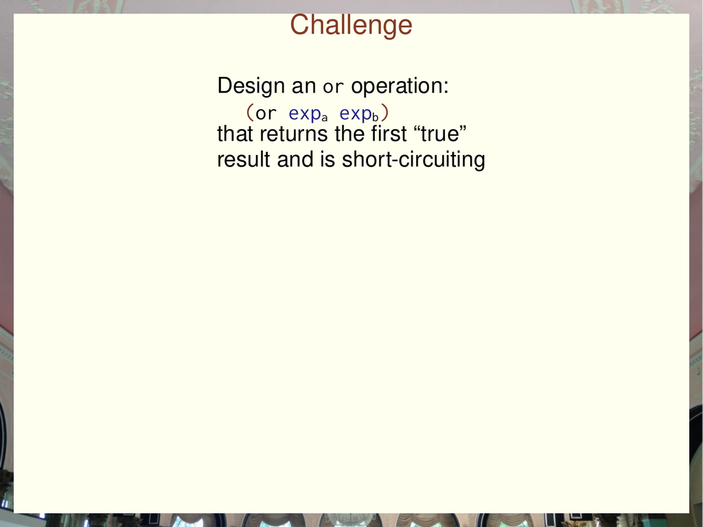

幻灯片 19 · 挑战：设计返回第一个非假值的短路 orSlide 19 · Challenge: design a short-circuiting or that returns the first true result

**幻灯片文字 / Slide text**

```
Challenge
Design an or operation:
(or expa expb)
that returns the first “true”
result and is short-circuiting
```

好，挑战来了：实现 or。你有一门不包含 or 的编程语言，我们想把它加进去。这个 or 应该像 C 的 or，或者 Lisp 的 or：先对第一个表达式求值，如果它返回的不是假值，那么这个返回值就是整个 or 表达式的值。Okay, so here's the challenge implement or okay, You have a programming language that doesn't have or in it, and we want to add that to the programming language, and this should be an or like sees or like the list bore where you evaluate the first expression. If it returns something, that's not false, that's the value of the entire or expression.

如果它返回假值，并且只有在它返回假值时，才对另一个表达式求值，然后用那个结果作为整个表达式的值。因此，它既有短路行为，而且布尔值也不只是两种，对吧，任何不为假的东西都算真，所以应该把它返回。好，我们会用这个示例函数来测试一堆有问题的 or 宏版本。If it returns false, and only if it returns false, then you evaluate the other expression, and then that should be the value, so it's both short circuiting and also there's not just two booleans right everything that's not false, it counts as true, and so you should return it okay, and this is the example function that we'll use to test out a bunch of bad versions of the ore macro.

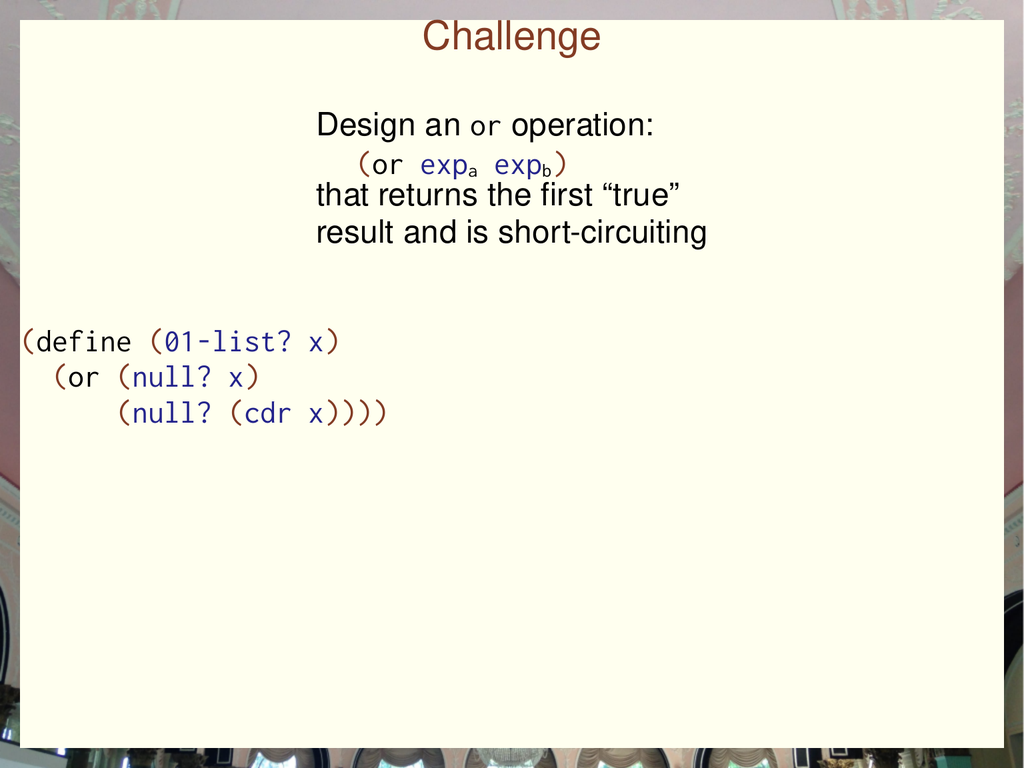

幻灯片 20 · 测试函数 01-list?：列表是否为空或只有一个元素Slide 20 · The 01-list? test: is the list empty or a singleton?

**幻灯片文字 / Slide text**

```
Challenge
Design an or operation:
(or expa expb)
that returns the first “true”
result and is short-circuiting
(define (01-list? x)
  (or (null? x)
(null? (cdr x))))
```

好，这个函数接收一个列表，当列表为空或者恰好只有一个元素时，返回真。好，这是第一个不成立的解决方案。Okay, so this is a function that, given a list returns true if the list is either empty or contains exactly one element in it all right, So here is non solution one.

## 宏语法详解Macro Syntax Explained

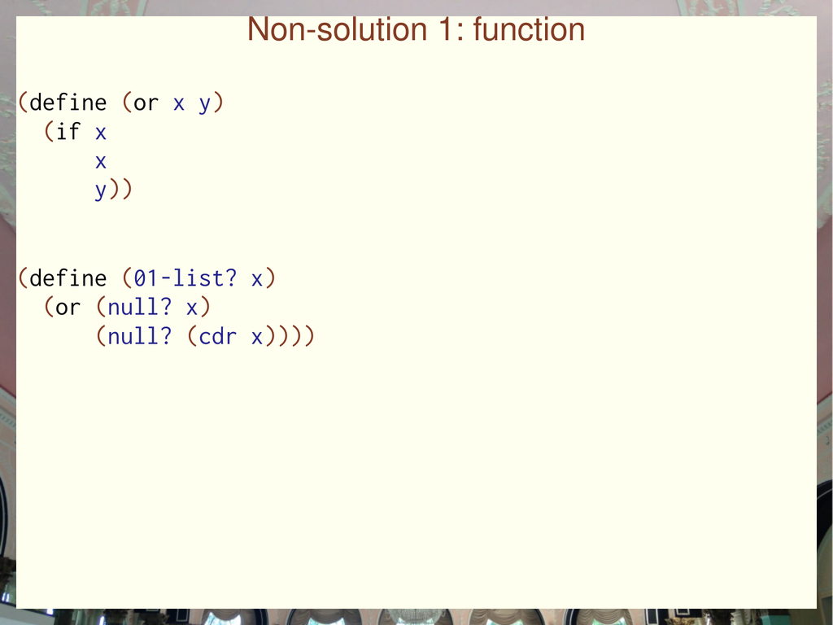

幻灯片 21 · 错误方案一：把 or 定义成普通函数Slide 21 · Non-solution 1: define or as an ordinary function

**幻灯片文字 / Slide text**

```
Non-solution 1: function
(define (or x y)
  (if x
x
y))
(define (01-list? x)
  (or (null? x)
(null? (cdr x))))
```

它甚至不是宏。如果把 or 定义成一个函数，然后用空列表调用这个判断列表长度是否为零或一的谓词，就会得到“给 cdr 传入了空列表”的错误。因为在按值调用的编程语言里，要先对函数的参数求值，再把它们代入函数体。这就是函数的含义。因此，这里发生的是，我们先计算 null? x。It's not even a macro if we define or as a function, and we call the zero one list predicate with the empty list, then we'll get could or given the empty list because in a call by value programming language, you evaluate the arguments to a function before you do the substitution into the body. That's what that's, what functions mean, and so what happens here is We evaluate null question mark of x.

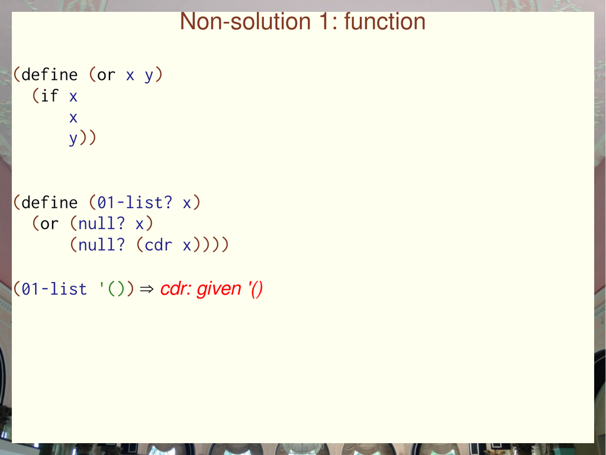

幻灯片 22 · 函数会先求值所有参数，因此 cdr 遇到空列表Slide 22 · Eager argument evaluation makes cdr receive the empty list

**幻灯片文字 / Slide text**

```
Non-solution 1: function
(define (or x y)
  (if x
x
y))
(define (01-list? x)
  (or (null? x)
(null? (cdr x))))
(01-list '()) ⇒ cdr: given '()
```

结果是真，但随后还会继续求值，因为 or 是个函数，于是就崩溃了。好，所以这样不行。使用函数无法得到短路行为，所以不能用函数来实现 or。对，在使用宏时，如果能用函数来做，就用函数。好，但这里不行，所以得用宏。That's true, but then we keep evaluating because or is a function, and so it crashes. Okay, So so this is not so, When you have a function, you can't get the short circuiting behavior, so we can't use a function to implement or right when you're working with macros if you can use a function to do it. okay, so here we can't, so we need to use a macro.

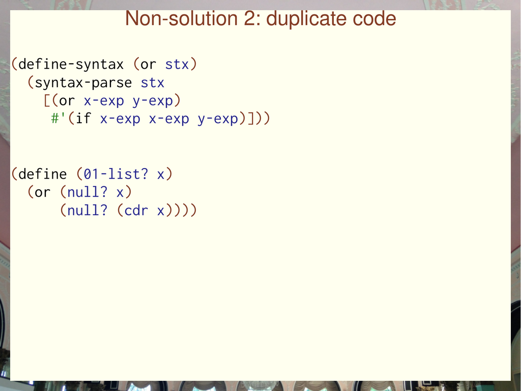

幻灯片 23 · 错误方案二：宏把条件表达式复制两次Slide 23 · Non-solution 2: the macro duplicates the condition

**幻灯片文字 / Slide text**

```
Non-solution 2: duplicate code
(define-syntax (or stx)
  (syntax-parse stx
  [(or x-exp y-exp)
#'(if x-exp x-exp y-exp)]))
(define (01-list? x)
  (or (null? x)
(null? (cdr x))))
```

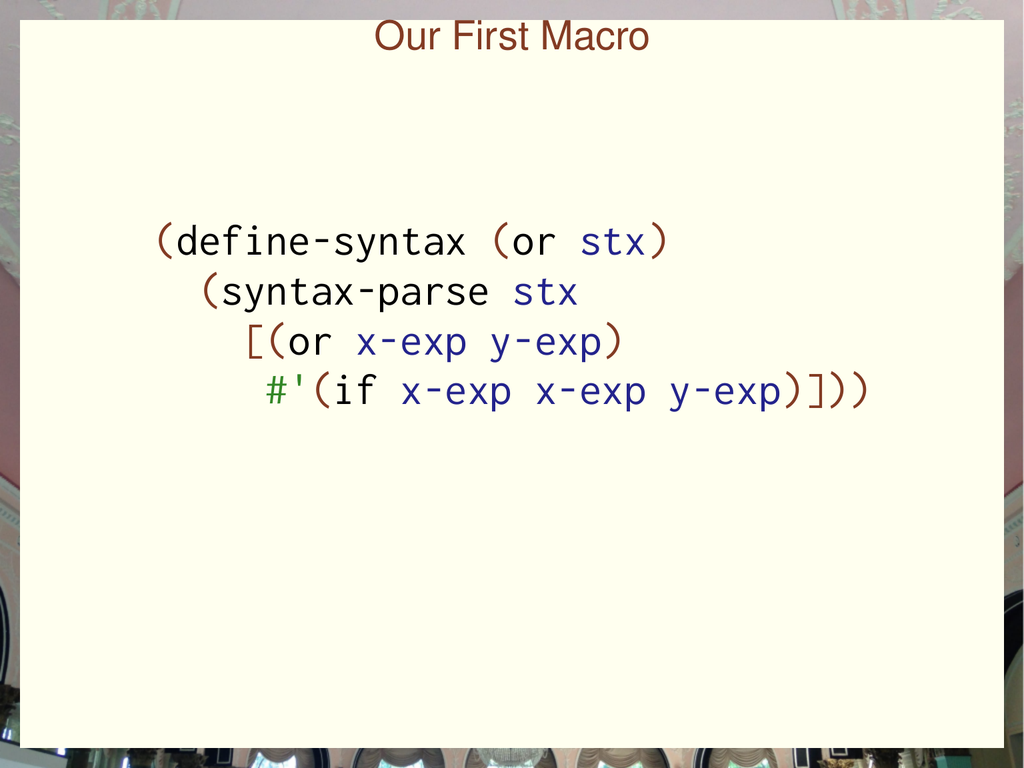

幻灯片 24 · 第一个宏：define-syntax、syntax-parse 与语法模板Slide 24 · Our first macro: define-syntax, syntax-parse and a syntax template

**幻灯片文字 / Slide text**

```
Our First Macro
(define-syntax (or stx)
  (syntax-parse stx
  [(or x-exp y-exp)
#'(if x-exp x-exp y-exp)]))
```

好，上面就是一个宏。让我放大一点，读一读这里的语法，让你们理解究竟是怎么回事，先跨过这些记法上的小障碍。首先是关键字 define-syntax。它的意思是，我在编译期定义某个东西。This is all right, so that's a macro up there. Let me zoom in a little bit on that and just read to you the syntax, so you can understand you know what's really going on with. Just sort of get over some of the notational hurdles here with this, So the first thing is the keyword define syntax. What that means is I'm defining something at compile time.

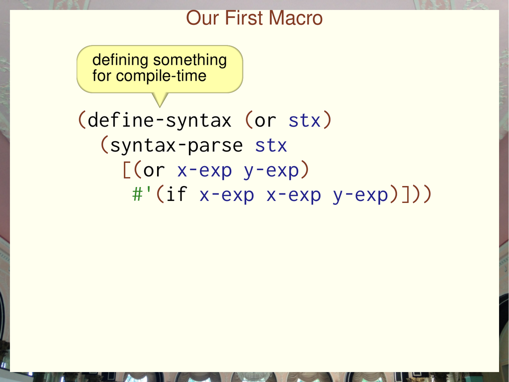

幻灯片 25 · define-syntax：在编译期定义绑定Slide 25 · define-syntax: defining something for compile time

**幻灯片文字 / Slide text**

```
Our First Macro
(define-syntax (or stx)
  (syntax-parse stx
  [(or x-exp y-exp)
#'(if x-exp x-exp y-exp)]))
defining something
for compile-time
```

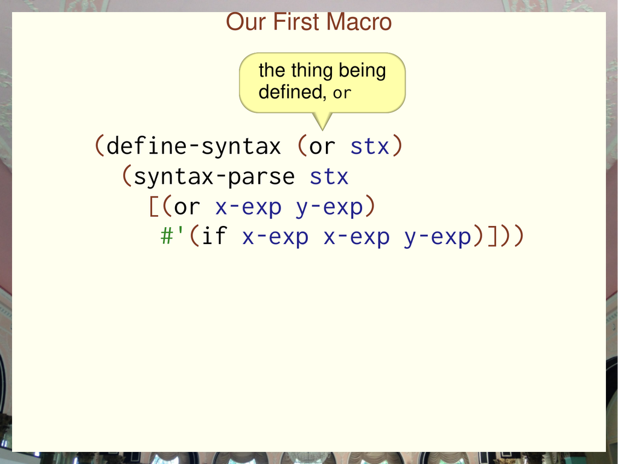

幻灯片 26 · 被定义的名称是 orSlide 26 · The thing being defined is or

**幻灯片文字 / Slide text**

```
Our First Macro
(define-syntax (or stx)
  (syntax-parse stx
  [(or x-exp y-exp)
#'(if x-exp x-exp y-exp)]))
the thing being
defined, or
```

它并不是说我在定义一个宏，对吧，它比单纯定义宏更一般。这碰巧是一个宏的定义，但 define-syntax 作为这门编程语言中的构造，表示在编译期定义某个东西。好，我们定义的东西是 or，并且把它定义成一个函数。It does not mean I'm defining a macro right, It's more general than just defining a macro. This happens to be the definition of a macro, but define syntax as a construct in the programming language means define something at compile time. Okay, so the thing we're defining is or and it's being defined to be a function.

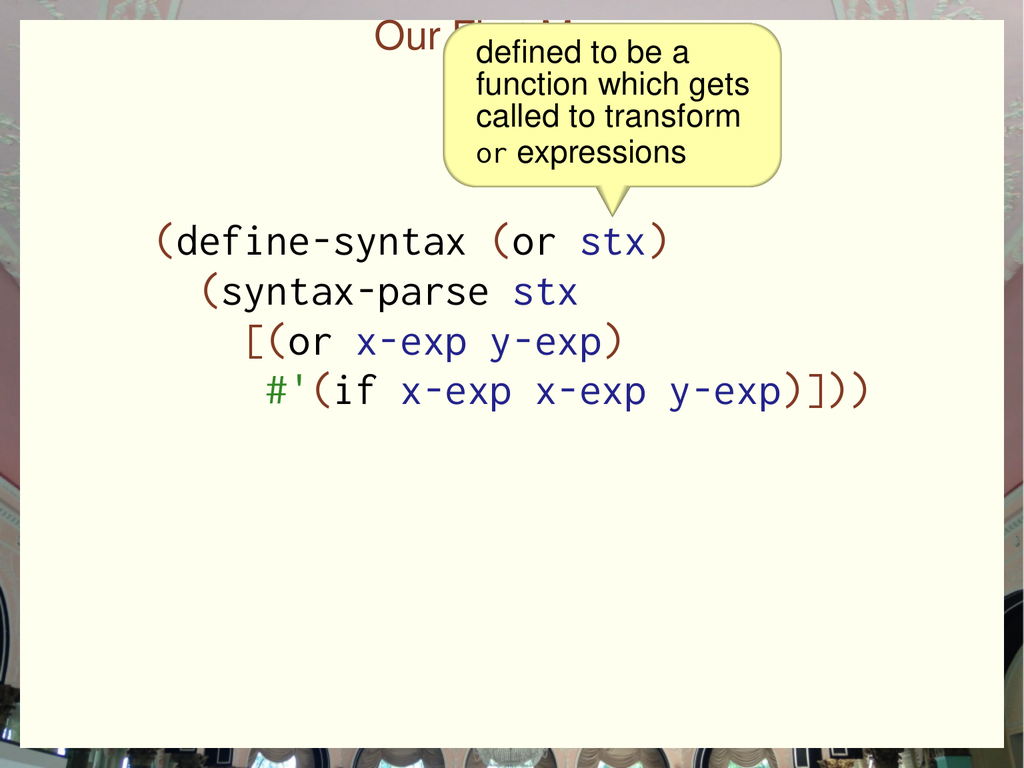

幻灯片 27 · 转换器是一个函数，接收要转换的完整 or 表达式Slide 27 · The transformer is a function that receives a complete or expression

**幻灯片文字 / Slide text**

```
Our First Macro
(define-syntax (or stx)
  (syntax-parse stx
  [(or x-exp y-exp)
#'(if x-exp x-exp y-exp)]))
defined to be a
function which gets
called to transform
or expressions
```

我没有把这个标记的小凸起画到括号周围，不过，它指的是括号以及那里的 stx 这个词。这表示，这里是在定义一个函数。因此，宏就是这么回事：宏是用 define-syntax 定义的函数。So I didn't put the put the little nub in of this thing around the parens, but it's both the parens and the word stx there. That means that this is being, This is the definition of a function, and so that's what a macro is. A macro is a function that's defined using defined syntax.

好，稍后我们还会回到这一点，因为你也可以定义其他不是函数的东西，它们会在宏系统中给你一些能力。好，我们把 or 定义成一个单参数函数，因此它是一个宏。那个参数——这与 Clojure 的宏系统不同——那个参数并不是 or 的参数，而是使用了 or 的整个表达式。好，现在进入函数体，函数体里发生的事情是……Okay, and we're going to return to this point later because you can define other things that aren't functions that give you some power in the macro system. Okay, so we're defining or is a function of one argument, and therefore it's a macro that one that one argument is, This is unlike closures macro system, and then that one argument is not kind of the argument to or that one argument is the entire expression that was at that was used by or okay. So then now we're in the body of the function and what happens in the body of the function is.

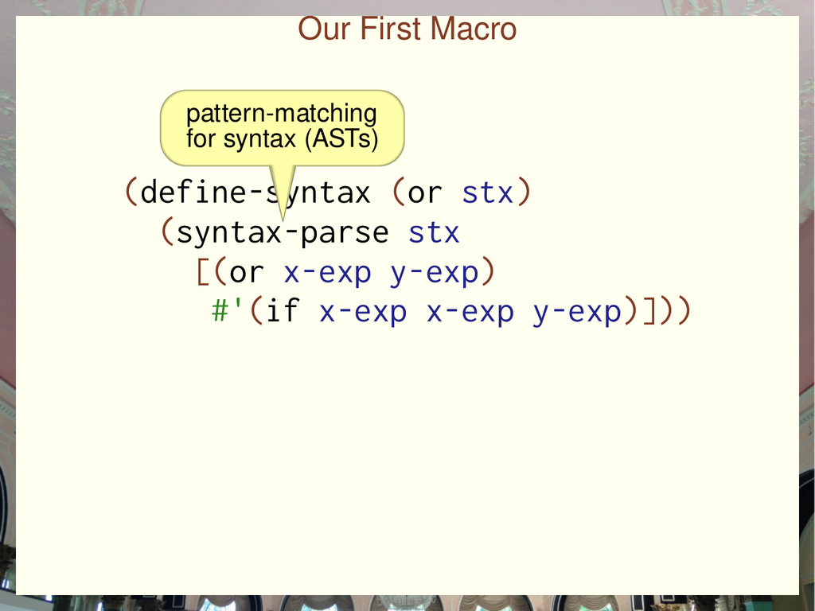

幻灯片 28 · syntax-parse：对语法树进行模式匹配Slide 28 · syntax-parse: pattern matching for syntax trees

**幻灯片文字 / Slide text**

```
Our First Macro
(define-syntax (or stx)
  (syntax-parse stx
  [(or x-exp y-exp)
#'(if x-exp x-exp y-exp)]))
pattern-matching
for syntax (ASTs)
```

我们使用一个叫 syntax-parse 的模式匹配库。我要对作为表达式的那棵树进行模式匹配。因为身处这个函数的函数体内，所以这个模式匹配是在编译期进行的。好，以方括号开头的这一行，紧跟在后面的内容，不包括方括号本身，就是我预期在那个位置出现的模式。We use this pattern matching library called syntax parse, so I'm going to pattern match on the tree that was the expression, and I'm going to be doing that pattern matching because I'm in the body of this function at compile time. Okay, this is the line that begins with the square bracket there, they're just following the rest of it, not including the square bracket. Is the pattern that I expect to appear at that point.

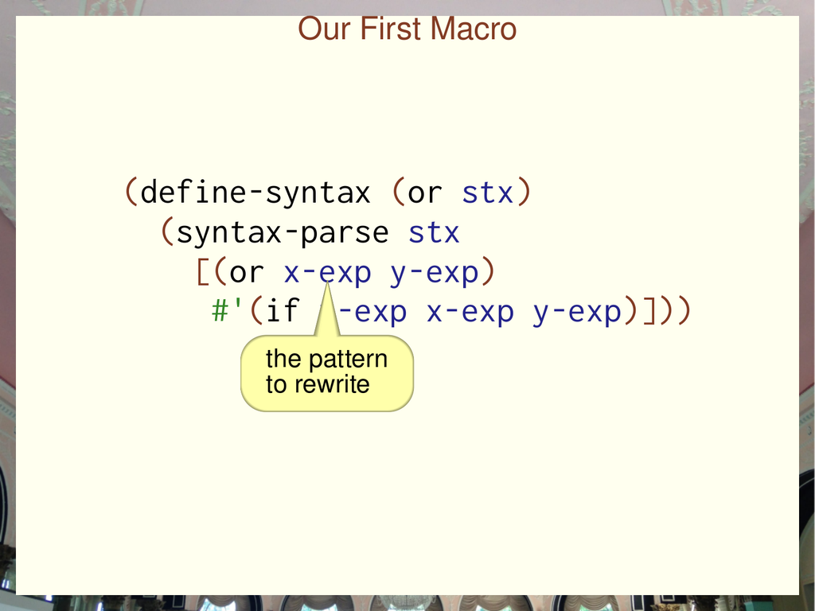

幻灯片 29 · 要重写的模式：(or x-exp y-exp)Slide 29 · The pattern to rewrite: (or x-exp y-exp)

**幻灯片文字 / Slide text**

```
Our First Macro
(define-syntax (or stx)
  (syntax-parse stx
  [(or x-exp y-exp)
#'(if x-exp x-exp y-exp)]))
the pattern
to rewrite
```

它应该是一个 or 表达式，所以应该以关键字 or 开头，然后有两个子表达式，x 表达式和 y 表达式。接下来这个东西就是宏的结果。我会把 or 表达式转换成 if 表达式。你们看这一行开头的 #'，井号加单引号，它表示我正在构造一个新的表达式。如果去掉 #'……So this should be an or expression, so it should begin with the keyword or and then it's got two sub expressions x and x expression of y expression, and then this thing is the result of the macro. So I'm going to transform my or expression into an if expression, and you see that hash tick at the beginning of the line hash quote That means I'm constructing a new expression if I left off the hash tick.

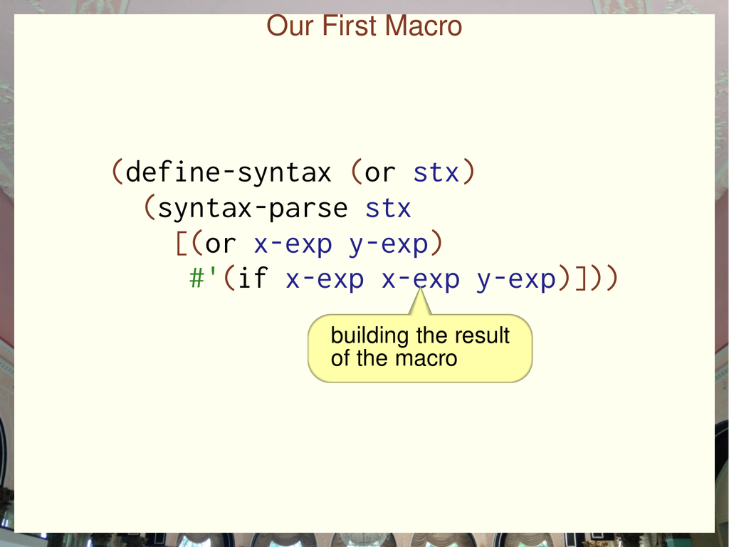

幻灯片 30 · #' 构造宏展开的结果，而不是在编译期执行 ifSlide 30 · #' constructs the macro result instead of executing if at compile time

**幻灯片文字 / Slide text**

```
Our First Macro
(define-syntax (or stx)
  (syntax-parse stx
  [(or x-exp y-exp)
#'(if x-exp x-exp y-exp)]))
building the result
of the macro
```